# Project 2: one-dimensional flow assumptions in a healthy aorta

## Introduction

One-dimensional blood-flow models describe a vessel using its area, flow rate and mean pressure. This is useful, but it assumes that the more detailed three-dimensional flow can be represented by a few quantities.

We use the healthy aorta **0012_H_AO_H** to examine those assumptions. We first measure the flow in cross-sections and check conservation. We then compare pressure, velocity-profile shape and friction with reference profiles. Finally, we calculate the remaining terms in the 1D momentum balance. The model has a rigid wall and a curved, branching geometry.

## Setup and supporting files

Keep this notebook, the scripts and `data/` in the same project folder. Install the packages in `requirements.txt`, then run the cells from the top. The README gives the setup commands. To regenerate all outputs from the terminal, use `python main.py`.

| File | What we use it for |
| --- | --- |
| `aorta_functions.py` | Reading the model, integrating sections and calculating references/balances |
| `prepare_volume.py` | Preparing the section data from the original volume; optional for this run |
| `main.py` | Running this notebook and saving its HTML preview |
| `export_html.py` | Refreshing the preview after saving changes made in Jupyter |
| `paraview_preview.py` | Inspecting the exported geometry in ParaView; optional |

The longer functions are in these files so the notebook can concentrate on the analysis. Their comments and docstrings explain their inputs and steps.

```python
from pathlib import Path
import os
import warnings

# Keep Matplotlib's cache beside the notebook.
os.environ.setdefault("MPLCONFIGDIR", str(Path.cwd() / ".matplotlib-cache"))
warnings.filterwarnings(
    "ignore",
    message="Setting the shape on a NumPy array.*",
    category=DeprecationWarning,
)

import numpy as np
import pandas as pd
import matplotlib.pyplot as plt
from matplotlib.colors import LogNorm
import pyvista as pv
import aorta_functions as af
```

### Parameters and units

The solver uses centimetres and dyn/cm². The reading functions convert the data to metres, m/s and Pa. We use the density, viscosity and period from the supplied model. Values involving net flow become unstable near zero, so we exclude phases below 5% of the local peak flow from those ratios.

```python
# Blood properties and timing, in SI units.
rho = 1060.0
mu = 0.004
nu = mu / rho
period = 0.937
solver_dt = 0.000937
low_flow_fraction = 0.05

closure_labels = {
    "poiseuille": "Poiseuille",
    "zeta9": "ζ = 9",
    "measured": "Measured α and f",
    "measured_alpha_poiseuille_f": "Measured α, Poiseuille f",
    "poiseuille_alpha_measured_f": "Poiseuille α, measured f",
}

# Results are saved in the same folder on every run.
project_folder = Path.cwd()
output_folder = project_folder / "results"
figure_folder = output_folder / "figures"
figure_folder.mkdir(parents=True, exist_ok=True)

plt.rcParams.update(
    {"font.size": 11, "figure.dpi": 110, "axes.grid": True, "grid.alpha": 0.2}
)


def save_figure(name):
    """Save the displayed figure as PNG and SVG."""
    plt.tight_layout()
    plt.savefig(figure_folder / f"{name}.png", dpi=180, bbox_inches="tight")
    plt.savefig(figure_folder / f"{name}.svg", bbox_inches="tight")
    plt.show()
```

## 1. Cross-sections, flow and conservation

The centreline gives the local downstream direction. We place sections perpendicular to it. Sections near branch junctions are excluded from the single-vessel balance because blood also leaves through the side branch. `load_geometry` reads the surfaces and the included VMTK centreline.

```python
# Load the anatomy and the section positions.
geometry = af.load_geometry(project_folder)
s = geometry["s_m"]
positions = geometry["points"]
tangents = geometry["tangents"]

geometry["table"].to_csv(output_folder / "geometry.csv", index=False)
print(f"{geometry['valid'].sum()} usable sections out of {len(s)} stations.")
```

```
47 usable sections out of 62 stations.
```

### Geometry preview

The grey points show the wall and the orange line follows the main aorta. The branch regions are omitted from derivative calculations, but the branch outlet flows are included in the global mass check.

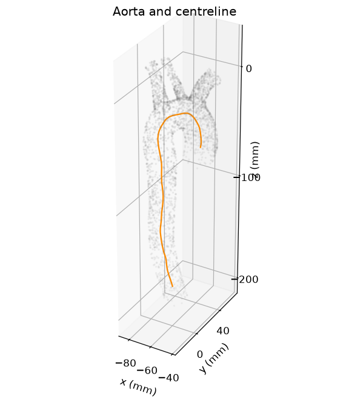

```python
# Use a subset of wall points to keep this preview light.
wall_points = geometry["wall"].points[::30] * 1000
fig = plt.figure(figsize=(8, 6))
ax = fig.add_subplot(111, projection="3d")
ax.scatter(
    wall_points[:, 0],
    wall_points[:, 1],
    wall_points[:, 2],
    s=2,
    alpha=0.3,
    color="grey",
)
ax.plot(
    positions[:, 0] * 1000,
    positions[:, 1] * 1000,
    positions[:, 2] * 1000,
    color="darkorange",
)
ax.set_box_aspect(np.ptp(geometry["wall"].points, axis=0))
for axis in [ax.xaxis, ax.yaxis, ax.zaxis]:
    axis.set_major_locator(plt.MaxNLocator(3))
ax.set(xlabel="x (mm)", ylabel="y (mm)", zlabel="z (mm)", title="Aorta and centreline")
save_figure("aorta_geometry")
```

### Inlet and outlet flow

For an incompressible fluid in a rigid vessel, inlet flow should equal the sum of outlet flows. Cap normals point out of the domain; the helper reports inlet flow as positive inflow. The saved snapshots cover one complete cycle.

```python
# Integrate velocity through each inlet/outlet surface.
time, steps, cap_flows = af.read_cap_flows(geometry, solver_dt, period)
cap_flows.to_csv(output_folder / "cap_flows_m3_s.csv", index=False)
inlet_flow = cap_flows["inflow"].to_numpy()
outlet_names = ["btrunk", "carotid", "subclavian", "outflow"]
outlet_flow = cap_flows[outlet_names].sum(axis=1).to_numpy()

# Scale the mismatch by peak inlet flow, including low-flow phases.
flow_scale = np.max(np.abs(inlet_flow))
mass_error = (inlet_flow - outlet_flow) / flow_scale
print(
    f"Maximum global mismatch: {np.max(np.abs(mass_error)) * 100:.3g}% of peak inlet flow."
)
```

```
Maximum global mismatch: 2.18e-05% of peak inlet flow.
```

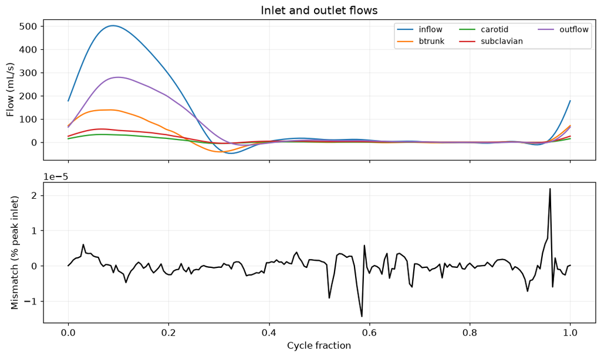

```python
fig, axes = plt.subplots(2, 1, sharex=True, figsize=(10, 6))
for name in ["inflow"] + outlet_names:
    axes[0].plot(time / period, cap_flows[name] * 1e6, label=name)
axes[0].set(ylabel="Flow (mL/s)", title="Inlet and outlet flows")
axes[0].legend(ncol=3, fontsize=9)
axes[1].plot(time / period, mass_error * 100, color="black")
axes[1].set(xlabel="Cycle fraction", ylabel="Mismatch (% peak inlet)")
save_figure("cap_flows_and_mass")
```

### Measurements in the filled sections

We use $u_s$, the velocity along the local tangent, to calculate $$Q=\int_A u_s\,dA,\qquad U=Q/A,\qquad \bar P=\frac{1}{A}\int_A P\,dA.$$ The functions weight the values by triangle area, since mesh points are not evenly spaced. The prepared archive contains actual pressure and velocity values from the 3D volume at all section points. It keeps the normal run manageable; the original volume is 5.55 GB.

```python
# Check and load the prepared section fields, then recompute the integrals.
sections, volume_metadata = af.load_sections(
    project_folder, geometry, nu, solver_dt, period
)
volume_time, fields, momentum, section_table = af.analyse_sections(
    sections, s, tangents, rho, nu, output_folder, low_flow_fraction
)
assert np.allclose(volume_time, time)
assert np.array_equal(sections["steps"], steps)

# Use a valid descending-aorta station for the detailed examples.
eligible = sections["section_ids"]
station = int(eligible[np.argmin(np.abs(s[eligible] - 0.20))])
peak_frame = int(np.nanargmax(fields["Q"][:, station]))
example = af.get_section(sections, geometry, station, peak_frame)
print(
    f"Example section: {s[station] * 1000:.0f} mm from the inlet at peak section flow."
)
```

```
Example section: 199 mm from the inlet at peak section flow.
```

The following plots show how area, flow and mean pressure vary along the vessel at the selected time. Gaps indicate excluded sections. A fall in main-vessel flow after a branch is expected because some blood leaves through that branch.

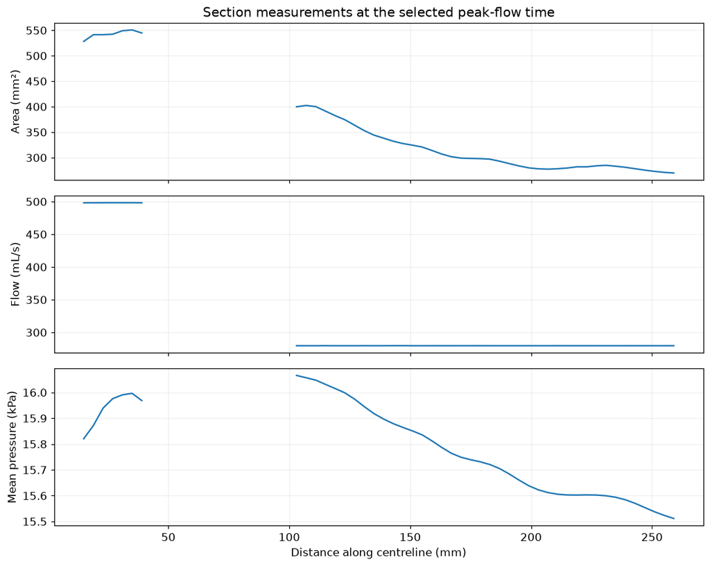

```python
fig, axes = plt.subplots(3, 1, sharex=True, figsize=(10, 8))
plot_values = [
    ("A", 1e6, "Area (mm²)"),
    ("Q", 1e6, "Flow (mL/s)"),
    ("P", 0.001, "Mean pressure (kPa)"),
]
for ax, (name, scale, label) in zip(axes, plot_values):
    ax.plot(s * 1000, fields[name][peak_frame] * scale)
    ax.set_ylabel(label)
axes[0].set_title("Section measurements at the selected peak-flow time")
axes[-1].set_xlabel("Distance along centreline (mm)")
save_figure("section_area_flow_pressure")
```

We also compare direct section flow with inlet flow minus the upstream branch flows. This checks that the local section measurements agree with the cap measurements, rather than checking only the whole-domain balance.

```
Maximum local difference: 0.350% of peak inlet flow.
```

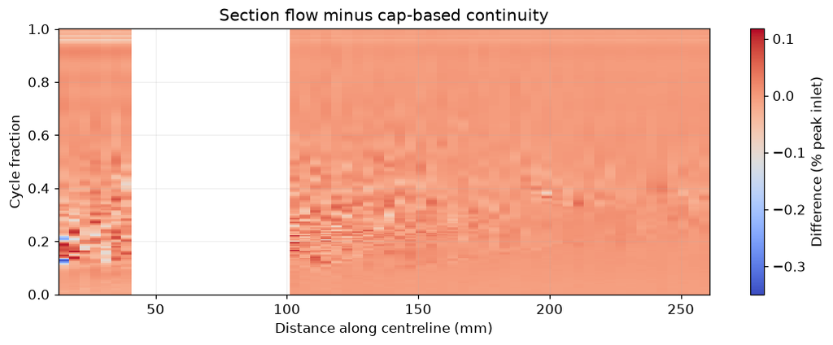

```python
# Account for flow leaving through each branch.
continuity_flow = np.tile(inlet_flow[:, None], (1, len(s)))
for name, branch_position in geometry["branch_locations"].items():
    continuity_flow[:, s > branch_position] -= cap_flows[name].to_numpy()[:, None]
local_mass_error = (fields["Q"] - continuity_flow) / flow_scale
print(
    f"Maximum local difference: {100 * np.nanmax(np.abs(local_mass_error)):.3f}% of peak inlet flow."
)

fig, ax = plt.subplots(figsize=(10, 4))
image = ax.pcolormesh(
    s * 1000, time / period, local_mass_error * 100, shading="auto", cmap="coolwarm"
)
ax.set(
    xlabel="Distance along centreline (mm)",
    ylabel="Cycle fraction",
    title="Section flow minus cap-based continuity",
)
fig.colorbar(image, ax=ax, label="Difference (% peak inlet)")
save_figure("local_mass_balance")
```

### Reynolds and Womersley numbers

These numbers put the measured flow in context. We use the diameter of a circle with the same section area, $D=2\sqrt{A/\pi}$, and calculate $$Re_D=\frac{|U|D}{\nu},\qquad Wo=\frac{D}{2}\sqrt{\frac{2\pi}{T\nu}}.$$ $Re_D$ compares convective inertia with viscosity and changes with flow. $Wo$ compares pulsatile inertia with viscosity. It stays constant over this cycle because the wall, viscosity and period are fixed.

The upper panel uses the same selected peak-flow time as the section measurements. The lower panel shows $Wo$ along the vessel. Both use the actual aorta. A large peak $Re_D$ alone does not establish turbulent flow in a pulsatile artery. Large $Wo$ helps explain why an instantaneous Poiseuille parabola can be a poor reference.

We write the pulsation number as $Wo$. The symbol $\alpha$ elsewhere in this notebook is the momentum-profile correction, a different quantity.

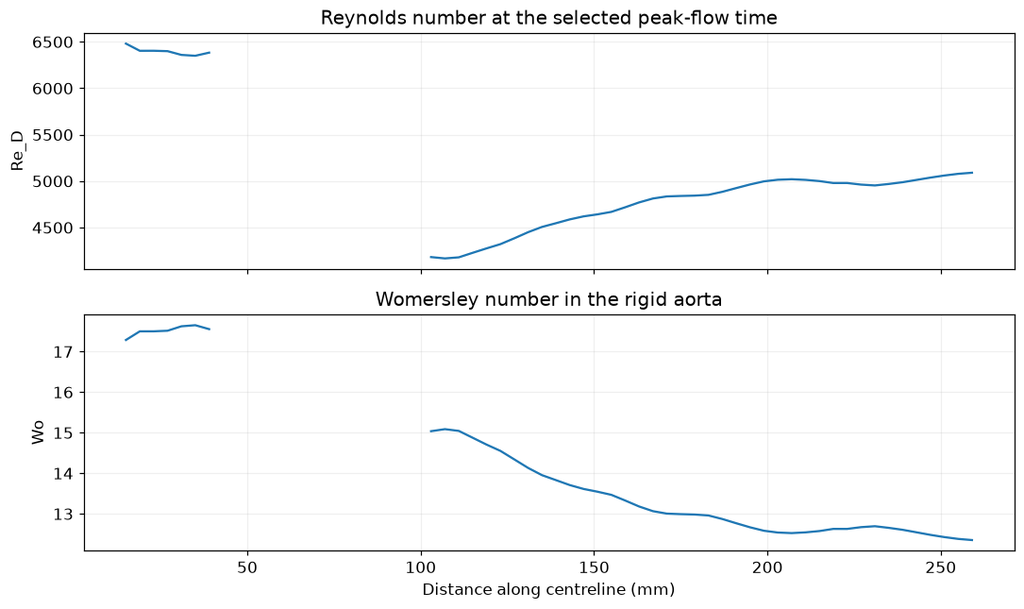

```
At 199 mm: peak-time Re_D = 4997, Wo = 12.58.
```

```python
diameter = 2 * np.sqrt(fields["A"][0] / np.pi)
reynolds = np.abs(fields["U"]) * diameter / nu
womersley = diameter / 2 * np.sqrt(2 * np.pi / (period * nu))

regime_table = section_table[["time_s", "s_m"]].copy()
regime_table["Re_D"] = reynolds.ravel()
regime_table["Wo"] = np.broadcast_to(womersley, reynolds.shape).ravel()
regime_table.to_csv(output_folder / "flow_regime_numbers.csv", index=False)

fig, axes = plt.subplots(2, 1, sharex=True, figsize=(10, 6))
axes[0].plot(s * 1000, reynolds[peak_frame])
axes[0].set(ylabel="Re_D", title="Reynolds number at the selected peak-flow time")
axes[1].plot(s * 1000, womersley)
axes[1].set(
    xlabel="Distance along centreline (mm)",
    ylabel="Wo",
    title="Womersley number in the rigid aorta",
)
save_figure("flow_regime_numbers")
print(
    f"At {s[station] * 1000:.0f} mm: peak-time Re_D = {reynolds[peak_frame, station]:.0f}, Wo = {womersley[station]:.2f}."
)
```

### Womersley check

Womersley describes pulsatile flow in a straight, circular, rigid tube. We check this known case before interpreting the curved aorta. The checks in `check_analytical_cases` recover the imposed mean velocity, zero wall velocity and the expected momentum balance. The plotted profile changes with phase, unlike a fixed Poiseuille parabola.

|  | check | error | units |
| --- | --- | --- | --- |
| 0 | Mean velocity recovery | 4.029196e-07 | m/s |
| 1 | Wall no-slip | 1.922301e-18 | m/s |
| 2 | Womersley momentum balance | 2.303930e-19 | m³/s² |

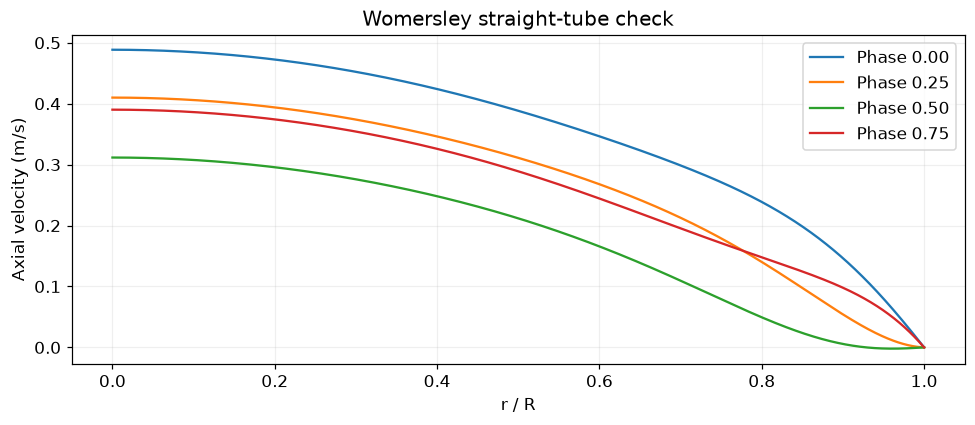

```python
# Known solutions check the numerical routines, not patient measurements.
reference, reference_errors = af.check_analytical_cases(rho, mu, period)
display(reference_errors)

fig, ax = plt.subplots(figsize=(9, 4))
for frame in [0, 50, 100, 150]:
    ax.plot(
        reference["r"] / reference["radius_m"],
        reference["velocity"][frame],
        label=f"Phase {reference['time_s'][frame] / period:.2f}",
    )
ax.set(
    xlabel="r / R", ylabel="Axial velocity (m/s)", title="Womersley straight-tube check"
)
ax.legend()
save_figure("womersley_check")
```

### Velocity profiles in the aorta

The points retain variation around the section, so their spread shows asymmetry at the same radius. Radius is divided by the area-equivalent radius; the actual boundary is not a perfect circle. Quarter and half interval refer to the saved cycle, not identified physiological phases. Dashed curves show the Womersley reference at the same times, using this section's measured mean-flow history and area-equivalent radius. This is a straight circular-tube comparison, not another aortic simulation.

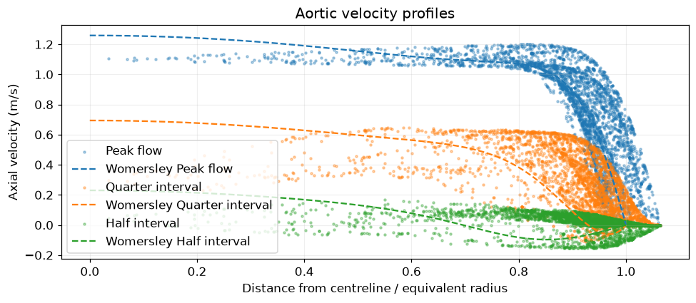

```python
mean_velocity = fields["U"][:, station]
radius = geometry["radius_m"][station]
local_reference = af.womersley_reference(time, mean_velocity, radius, nu, period)

fig, ax = plt.subplots(figsize=(9, 4))
profile_frames = [
    (peak_frame, "Peak flow", "tab:blue"),
    (len(time) // 4, "Quarter interval", "tab:orange"),
    (len(time) // 2, "Half interval", "tab:green"),
]
for frame, label, colour in profile_frames:
    section = af.get_section(sections, geometry, station, frame)
    ax.scatter(
        section["normalised_radius"],
        section["axial_velocity"],
        s=4,
        alpha=0.35,
        color=colour,
        label=label,
    )
    ax.plot(
        local_reference["r"] / radius,
        local_reference["velocity"][frame],
        "--",
        color=colour,
        label=f"Womersley {label}",
    )
ax.set(
    xlabel="Distance from centreline / equivalent radius",
    ylabel="Axial velocity (m/s)",
    title="Aortic velocity profiles",
)
ax.legend()
save_figure("aortic_velocity_profiles")
```

## 2. Pressure, profile shape and friction

A 1D description uses one pressure per section. We first show pressure relative to the section mean and the signed axial velocity at peak flow. Negative velocity means local reverse flow. Both maps use coordinates within the section plane.

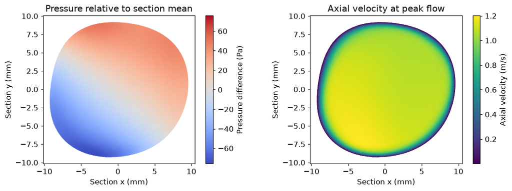

```python
# These local coordinates are prepared by get_section.
x, y = example["plot_x_mm"], example["plot_y_mm"]
triangles = example.regular_faces
pressure_difference = example["pressure"] - fields["P"][peak_frame, station]
pressure_limit = np.max(np.abs(pressure_difference))

fig, axes = plt.subplots(1, 2, figsize=(11, 4))
image = axes[0].tripcolor(
    x,
    y,
    triangles,
    pressure_difference,
    shading="gouraud",
    cmap="coolwarm",
    vmin=-pressure_limit,
    vmax=pressure_limit,
)
axes[0].set(
    title="Pressure relative to section mean",
    xlabel="Section x (mm)",
    ylabel="Section y (mm)",
)
fig.colorbar(image, ax=axes[0], label="Pressure difference (Pa)")

image = axes[1].tripcolor(
    x, y, triangles, example["axial_velocity"], shading="gouraud", cmap="viridis"
)
axes[1].set(
    title="Axial velocity at peak flow",
    xlabel="Section x (mm)",
    ylabel="Section y (mm)",
)
fig.colorbar(image, ax=axes[1], label="Axial velocity (m/s)")
for ax in axes:
    ax.set_aspect("equal")
save_figure("section_pressure_velocity")
```

### Changes along the vessel and cycle

The maps test mostly axial flow, uniform pressure and a fixed profile shape. The secondary-flow ratio compares in-plane and axial RMS velocity. Pressure range is divided by the dynamic pressure $\rho U^2/2$. The momentum correction is $$\alpha=\frac{A\int_A u_s^2\,dA}{Q^2}.$$ The pressure ratios and $\alpha$ are masked below 5% of local peak net flow. The secondary-flow ratio uses RMS velocity and keeps those phases. The extra pressure panel divides the cross-sectional range by the local axial drop, $|\partial_s\bar P|\Delta s$, over approximately 4 mm. This ratio depends on the chosen spacing. Tiny axial drops are excluded, and a large ratio alone does not prove that the 1D balance is invalid. Logarithmic colours show the wide range of positive pressure/profile values.

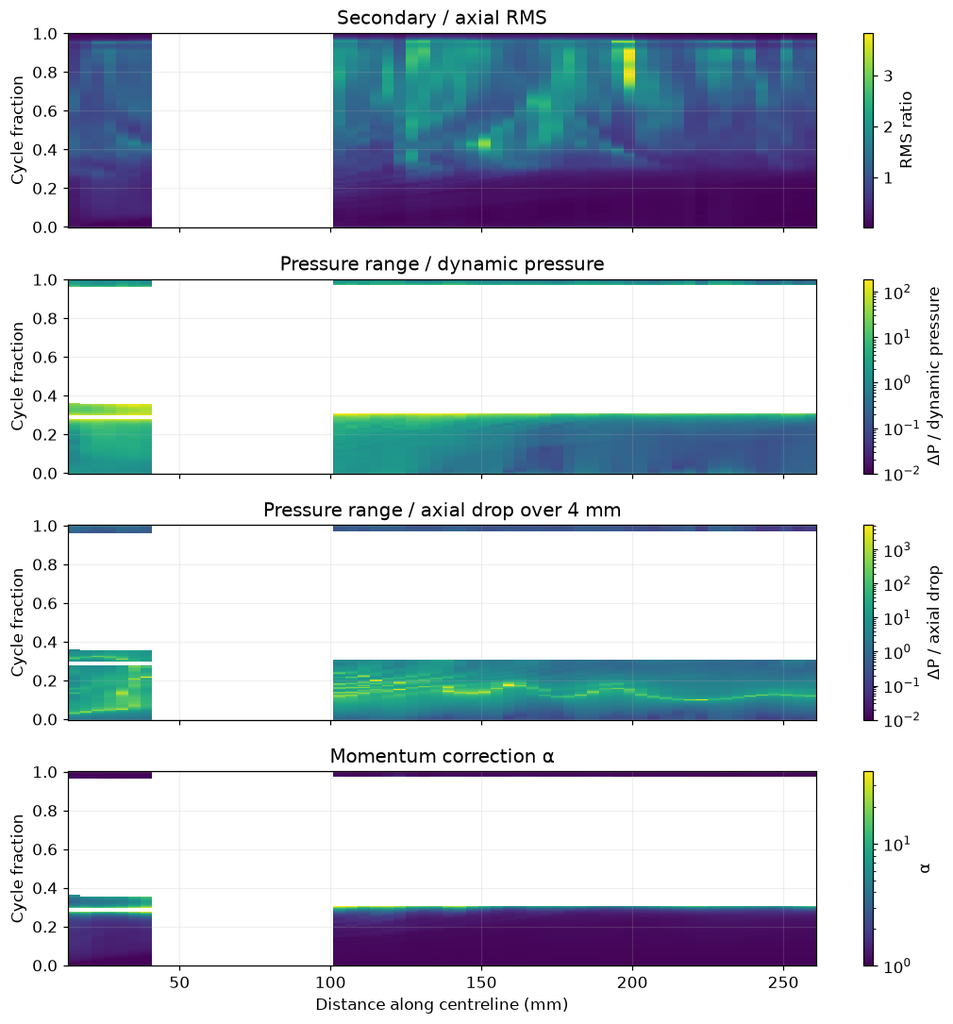

```python
fig, axes = plt.subplots(4, 1, sharex=True, figsize=(10, 10))
map_items = [
    ("secondary_ratio", "Secondary / axial RMS", None),
    (
        "pressure_dynamic_ratio",
        "Pressure range / dynamic pressure",
        LogNorm(vmin=0.01, vmax=np.nanmax(fields["pressure_dynamic_ratio"])),
    ),
    (
        "pressure_axial_ratio",
        "Pressure range / axial drop over 4 mm",
        LogNorm(vmin=0.01, vmax=np.nanmax(fields["pressure_axial_ratio"])),
    ),
    (
        "alpha",
        "Momentum correction α",
        LogNorm(vmin=1, vmax=np.nanmax(fields["alpha"])),
    ),
]
for ax, (name, label, colour_scale) in zip(axes, map_items):
    image = ax.pcolormesh(
        s * 1000,
        time / period,
        fields[name],
        shading="auto",
        cmap="viridis",
        norm=colour_scale,
    )
    ax.set(ylabel="Cycle fraction", title=label)
    colour_labels = {
        "secondary_ratio": "RMS ratio",
        "pressure_dynamic_ratio": "ΔP / dynamic pressure",
        "pressure_axial_ratio": "ΔP / axial drop",
        "alpha": "α",
    }
    fig.colorbar(image, ax=ax, label=colour_labels[name])
axes[-1].set_xlabel("Distance along centreline (mm)")
save_figure("pressure_and_profile_maps")
```

### Reference profiles

Poiseuille gives $\alpha=4/3$. The blunter $\zeta=9$ profile gives $\alpha=1.1$. Womersley allows the shape to vary over time. We give the Womersley reference the measured mean velocity at the selected section, so the comparisons use the same bulk-flow history. It remains a straight-tube reference. The Womersley curve uses a 1% low-flow cutoff, so its gaps can differ from the 5% cutoff used for the actual section.

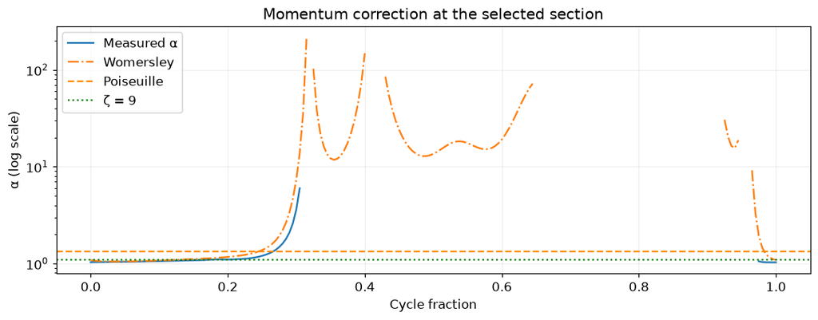

```python
# Compare profile factors using the same section flow history.

fig, ax = plt.subplots(figsize=(10, 4))
ax.plot(time / period, fields["alpha"][:, station], label="Measured α")
ax.plot(time / period, local_reference["alpha"], "-.", label="Womersley")
ax.axhline(4 / 3, color="darkorange", linestyle="--", label="Poiseuille")
ax.axhline(1.1, color="green", linestyle=":", label="ζ = 9")
ax.set_yscale("log")
ax.set(
    xlabel="Cycle fraction",
    ylabel="α (log scale)",
    title="Momentum correction at the selected section",
)
ax.legend()
save_figure("profile_factor_comparison")
```

### Alpha versus time at the selected section

This annotated view uses the same measured $\alpha$ as the comparison above, at the same descending-aorta section near 199 mm. The horizontal axis is **time in seconds within the cycle**, rather than cycle fraction. The vertical axis is dimensionless $\alpha$ on a **linear scale**. The dashed line shows the constant Poiseuille value $4/3$.

We retain all 201 time samples and leave masked values missing. Grey shading identifies phases where the absolute net flow is below 5% of that section's peak absolute flow. It represents a withheld ratio, not zero $\alpha$ or missing simulation snapshots. The plotting details live in `aorta_functions.py`, in `plot_alpha_time`.

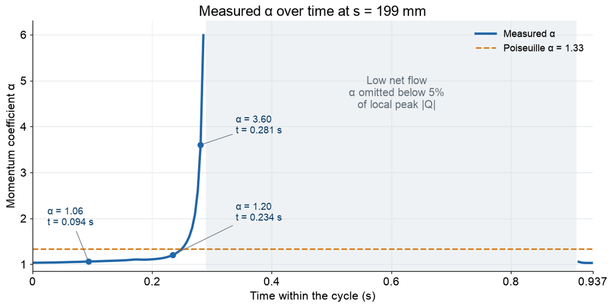

```python
alpha_history = pd.DataFrame(
    {
        "time_s": time,
        "alpha": fields["alpha"][:, station],
        "Q": fields["Q"][:, station],
    }
)
alpha_history.to_csv(output_folder / "alpha_vs_time.csv", index=False)
af.plot_alpha_time(alpha_history, s[station], low_flow_fraction)
save_figure("alpha_vs_time")
```

At peak flow, $t=0.0937$ s, measured $\alpha$ is about **1.06**. It reaches **1.20** at $0.23425$ s and **3.60** at $0.28110$ s. Thus the measured correction varies with phase at this section. A constant $\alpha$ remains a possible model approximation, but it cannot reproduce all these values exactly. This figure alone does not decide which constant gives the best overall 1D approximation.

The strong rise near low net flow needs care because $\alpha=A\int_A u_s^2\,dA/Q^2$. Local forward and reverse velocities can cancel in $Q$ while the squared-velocity integral remains positive. The large ratio therefore does not by itself establish strong secondary flow, turbulence or disease. We withhold it below the existing 5% cutoff. For this section, 68 values remain and 133 are masked, from $0.290470$ to $0.908890$ s.

### Wall friction

The resisting-force term is $f=K_R U$, with $K_R=8\pi\nu$ for Poiseuille and $22\pi\nu$ for $\zeta=9$. The measured estimate comes from signed near-wall velocity gradients. Its sign and phase matter in the momentum equation. We compare it with the three references below.

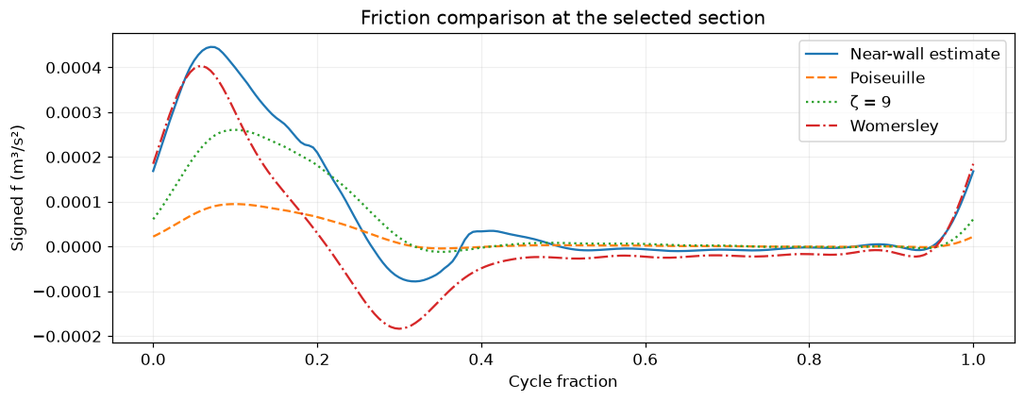

```python
fig, ax = plt.subplots(figsize=(10, 4))
ax.plot(time / period, fields["f_measured"][:, station], label="Near-wall estimate")
ax.plot(time / period, 8 * np.pi * nu * mean_velocity, "--", label="Poiseuille")
ax.plot(time / period, 22 * np.pi * nu * mean_velocity, ":", label="ζ = 9")
ax.plot(time / period, local_reference["friction"], "-.", label="Womersley")
ax.set(
    xlabel="Cycle fraction",
    ylabel="Signed f (m³/s²)",
    title="Friction comparison at the selected section",
)
ax.legend()
save_figure("friction_comparison")
```

### Profile shape and friction along the vessel

We repeat the comparison at every usable section, at the same fixed peak-flow time. The vertical line marks the 199 mm example section. This shows how representative that example is. The profile factor uses the local velocity field; the friction references use the local mean speed. Gaps remain at excluded branch sections.

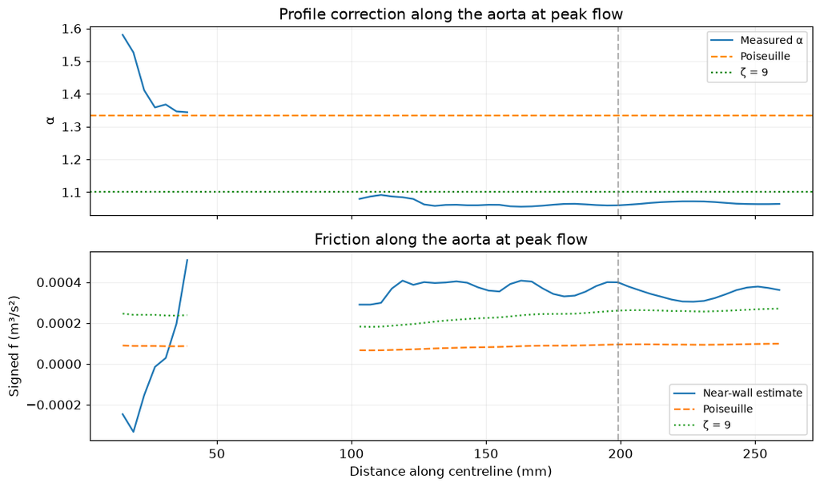

```python
fig, axes = plt.subplots(2, 1, sharex=True, figsize=(10, 6))
axes[0].plot(s * 1000, fields["alpha"][peak_frame], label="Measured α")
axes[0].axhline(4 / 3, color="darkorange", linestyle="--", label="Poiseuille")
axes[0].axhline(1.1, color="green", linestyle=":", label="ζ = 9")
axes[0].set(ylabel="α", title="Profile correction along the aorta at peak flow")
axes[1].plot(s * 1000, fields["f_measured"][peak_frame], label="Near-wall estimate")
axes[1].plot(
    s * 1000, 8 * np.pi * nu * fields["U"][peak_frame], "--", label="Poiseuille"
)
axes[1].plot(s * 1000, 22 * np.pi * nu * fields["U"][peak_frame], ":", label="ζ = 9")
axes[1].set(
    xlabel="Distance along centreline (mm)",
    ylabel="Signed f (m³/s²)",
    title="Friction along the aorta at peak flow",
)
for ax in axes:
    ax.axvline(s[station] * 1000, color="grey", linestyle="--", alpha=0.6)
    ax.legend(fontsize=9)
save_figure("profile_and_friction_along_vessel")
```

## 3. The one-dimensional momentum balance

We evaluate $$R=\partial_t Q+\partial_s(\alpha Q^2/A)+\frac{A}{\rho}\partial_s\bar P+f.$$ The terms are local acceleration, convective transport, pressure and friction. A small residual means that these terms nearly cancel. We divide $|R|$ by the sum of their magnitudes to compare different positions and times. A small denominator floor avoids dividing by a nearly zero term scale. This is a balance check, not an error against an experimental measurement.

We compare Poiseuille, $\zeta=9$, and measured profile/friction information. All three use the same pressure, area and flow data. The colour scale stops at 0.5; larger values share the brightest colour. White areas are unavailable calculations, not zero residual. The measured panel has extra gaps where low-flow masking makes $\alpha$ unavailable.

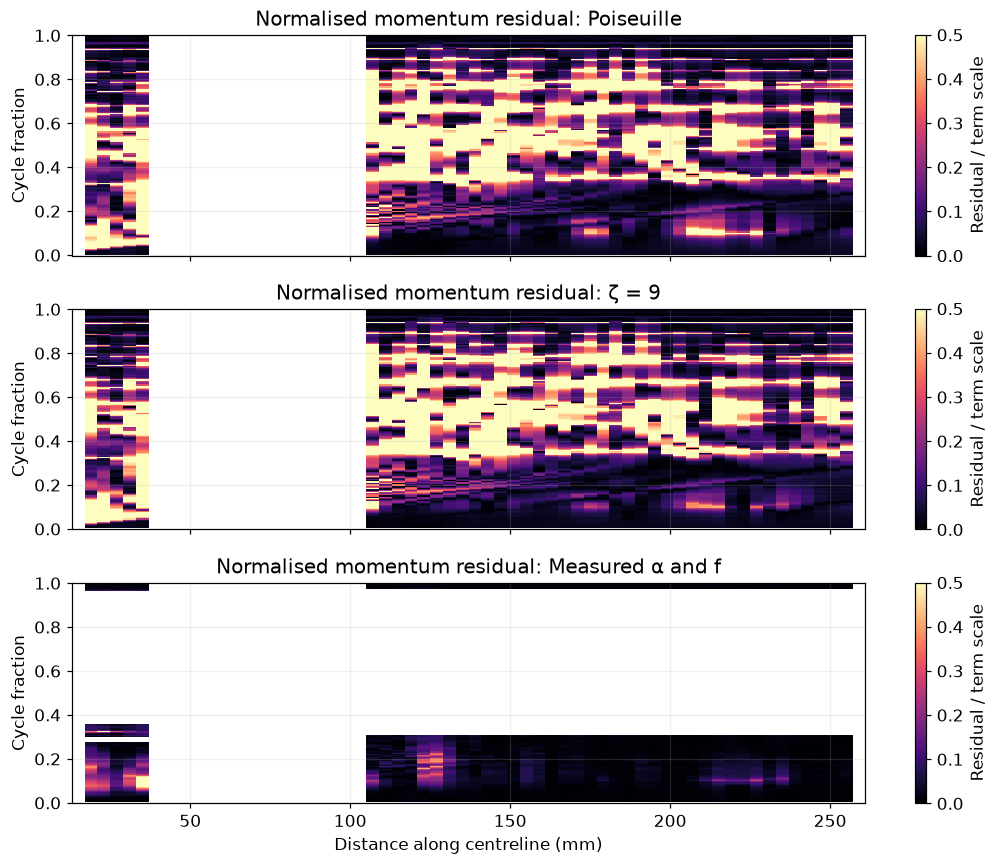

```python
fig, axes = plt.subplots(3, 1, sharex=True, figsize=(10, 8))
for ax, name in zip(axes, ["poiseuille", "zeta9", "measured"]):
    image = ax.pcolormesh(
        s * 1000,
        time / period,
        momentum[name]["normalized"],
        shading="auto",
        cmap="magma",
        vmin=0,
        vmax=0.5,
    )
    ax.set(
        ylabel="Cycle fraction",
        title=f"Normalised momentum residual: {closure_labels[name]}",
    )
    fig.colorbar(image, ax=ax, label="Residual / term scale")
axes[-1].set_xlabel("Distance along centreline (mm)")
save_figure("momentum_residual_maps")
```

At the selected section, the next plot shows the signed terms. Large terms can cancel, so inspecting only the residual would miss part of the picture. Branch neighbourhoods and derivative endpoints are excluded from residuals.

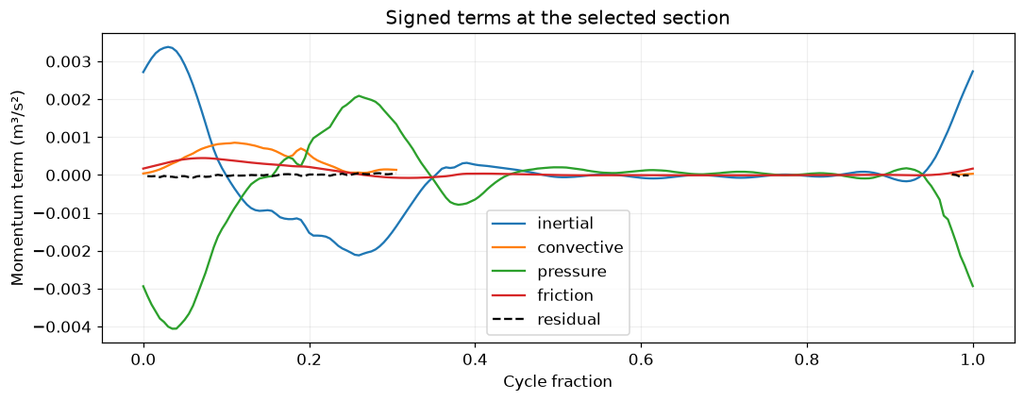

```python
fig, ax = plt.subplots(figsize=(10, 4))
for name in ["inertial", "convective", "pressure", "friction"]:
    ax.plot(time / period, momentum["measured"][name][:, station], label=name)
ax.plot(
    time / period, momentum["measured"]["residual"][:, station], "k--", label="residual"
)
ax.set(
    xlabel="Cycle fraction",
    ylabel="Momentum term (m³/s²)",
    title="Signed terms at the selected section",
)
ax.legend()
save_figure("momentum_term_budget")
```

### Comparing residuals fairly

We use the same available station–time pairs for every row. Otherwise, a curve with more missing low-flow values could appear better simply because fewer difficult points were included. The median describes typical values; the 95th percentile shows that larger residuals still occur. The two mixed rows change one ingredient at a time relative to Poiseuille. They separate the effect of using measured α from the effect of using the near-wall force estimate. These are consistency tests using the same simulation data, not an independent measurement of closure accuracy.

```python
common = np.isfinite(momentum["measured"]["normalized"])
residual_rows = []
for name in closure_labels:
    values = momentum[name]["normalized"][common]
    residual_rows.append(
        {
            "closure": name,
            "common_valid_pairs": int(common.sum()),
            "median_normalized_residual": np.median(values),
            "95th_percentile_normalized_residual": np.quantile(values, 0.95),
        }
    )
residual_summary = pd.DataFrame(residual_rows)
residual_summary.to_csv(output_folder / "closure_residual_statistics.csv", index=False)
display(residual_summary.round(4))
```

|  | closure | common_valid_pairs | median_normalized_residual | 95th_percentile_normalized_residual |
| --- | --- | --- | --- | --- |
| 0 | poiseuille | 2878 | 0.0456 | 0.4958 |
| 1 | zeta9 | 2878 | 0.0436 | 0.4543 |
| 2 | measured | 2878 | 0.0117 | 0.1751 |
| 3 | measured_alpha_poiseuille_f | 2878 | 0.0472 | 0.2512 |
| 4 | poiseuille_alpha_measured_f | 2878 | 0.0468 | 0.4188 |

### Residual over the cycle

At each time we compare the median residual over the same available locations for all five rows above. The lower panel shows how many locations remain. A gap means that no matched comparison is available. It does not mean the balance is exact during that phase. This view makes the low-flow coverage limit visible alongside the residual.

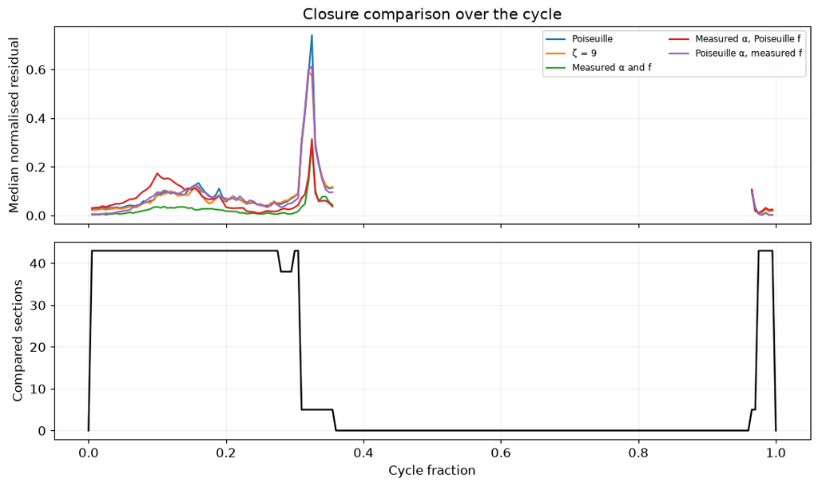

```python
paired_counts = common.sum(axis=1)
available_times = paired_counts > 0
cycle_table = pd.DataFrame(
    {"time_s": time, "cycle_fraction": time / period, "paired_sections": paired_counts}
)
fig, axes = plt.subplots(2, 1, sharex=True, figsize=(10, 6))
for name, label in closure_labels.items():
    values = np.where(common, momentum[name]["normalized"], np.nan)
    median = np.full(len(time), np.nan)
    median[available_times] = np.nanmedian(values[available_times], axis=1)
    cycle_table[name] = median
    axes[0].plot(time / period, median, label=label)
axes[0].set(
    ylabel="Median normalised residual", title="Closure comparison over the cycle"
)
axes[0].legend(fontsize=8, ncol=2)
axes[1].plot(time / period, paired_counts, color="black")
axes[1].set(xlabel="Cycle fraction", ylabel="Compared sections")
cycle_table.to_csv(output_folder / "residual_over_cycle.csv", index=False)
save_figure("residual_over_cycle")
```

### Residual and curvature

Curvature measures how quickly the centreline bends, in 1/m. We compare it with the three primary residuals at one fixed peak-flow time, using only sections where all are available. Each point is a location in the same aorta, not another model. The full-cycle summary above answers a different question from this single-time spatial comparison.

This plot tests a proposed link between bending and residual. A trend would show an association, not prove that curvature causes the imbalance. Pressure, area, friction estimates and sampling also vary along the vessel. The excluded branch region limits what we can conclude about the arch.

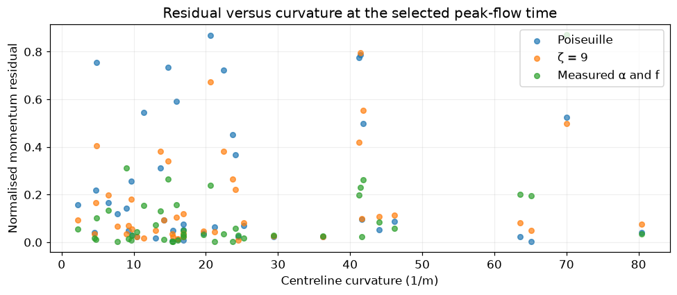

```
Compared 43 locations at cycle fraction 0.10.
```

```python
curvature = geometry["table"]["curvature_per_m"].to_numpy()
paired = common[peak_frame] & np.isfinite(curvature)
curvature_table = pd.DataFrame(
    {
        "s_m": s[paired],
        "time_s": time[peak_frame],
        "curvature_per_m": curvature[paired],
        "poiseuille_residual": momentum["poiseuille"]["normalized"][peak_frame, paired],
        "zeta9_residual": momentum["zeta9"]["normalized"][peak_frame, paired],
        "measured_residual": momentum["measured"]["normalized"][peak_frame, paired],
    }
)
curvature_table.to_csv(output_folder / "curvature_residual_comparison.csv", index=False)

fig, ax = plt.subplots(figsize=(9, 4))
for name in ["poiseuille", "zeta9", "measured"]:
    ax.scatter(
        curvature_table["curvature_per_m"],
        curvature_table[f"{name}_residual"],
        s=24,
        alpha=0.7,
        label=closure_labels[name],
    )
ax.set(
    xlabel="Centreline curvature (1/m)",
    ylabel="Normalised momentum residual",
    title="Residual versus curvature at the selected peak-flow time",
)
ax.legend()
save_figure("curvature_residual_comparison")
print(
    f"Compared {paired.sum()} locations at cycle fraction {time[peak_frame] / period:.2f}."
)
```

### A small sensitivity check

Wall force needs a derivative close to the wall. We compare estimates from 0.30 and 0.15 mm probe depths. A large difference limits how confidently we can interpret the residual. This check does not establish mesh convergence.

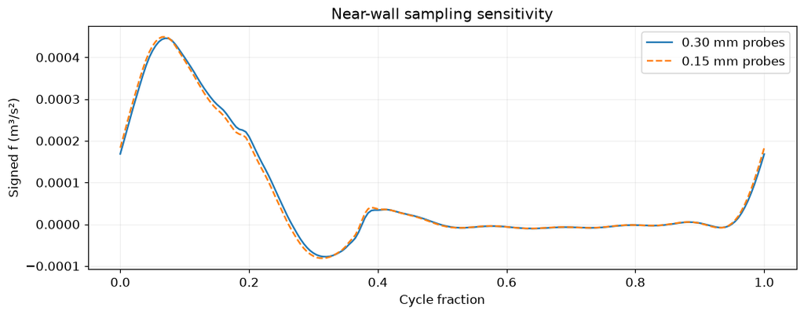

```python
fig, ax = plt.subplots(figsize=(10, 4))
ax.plot(time / period, fields["f_measured"][:, station], label="0.30 mm probes")
ax.plot(time / period, fields["f_half_depth"][:, station], "--", label="0.15 mm probes")
ax.set(
    xlabel="Cycle fraction",
    ylabel="Signed f (m³/s²)",
    title="Near-wall sampling sensitivity",
)
ax.legend()
save_figure("wall_probe_sensitivity")
```

### Probe sensitivity across all usable sections

We also compare both probe depths across the whole available dataset. For each section we divide their absolute difference by that section's peak 0.30 mm force magnitude. This avoids dividing by an instantaneous force close to zero. The histogram describes sensitivity to probe depth, not uncertainty against an independent wall-force measurement. Its samples are related in space and time.

```
Probe difference / local peak force: median 0.27%, 95th percentile 5.19%.
```

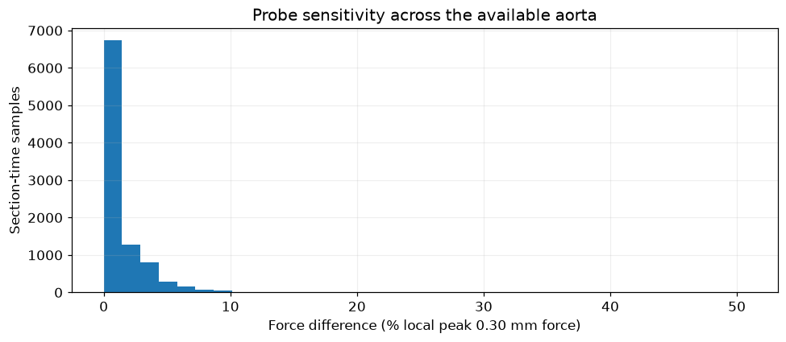

```python
first_force = fields["f_measured"][:, eligible]
second_force = fields["f_half_depth"][:, eligible]
peak_force = np.max(np.abs(first_force), axis=0)
assert np.all(peak_force > 0)
probe_difference = np.abs(second_force - first_force) / peak_force
probe_table = pd.DataFrame(
    {
        "time_s": np.repeat(time, len(eligible)),
        "s_m": np.tile(s[eligible], len(time)),
        "difference_over_local_peak_force": probe_difference.ravel(),
    }
)
probe_table.to_csv(output_folder / "probe_sensitivity_all_sections.csv", index=False)
median_probe, p95_probe = np.quantile(probe_difference, [0.5, 0.95])
print(
    f"Probe difference / local peak force: median {100 * median_probe:.2f}%, 95th percentile {100 * p95_probe:.2f}%."
)
fig, ax = plt.subplots(figsize=(9, 4))
ax.hist(probe_difference.ravel() * 100, bins=35)
ax.set(
    xlabel="Force difference (% local peak 0.30 mm force)",
    ylabel="Section-time samples",
    title="Probe sensitivity across the available aorta",
)
save_figure("probe_sensitivity_all_sections")
```

## Findings and limitations

We summarise the measured conservation errors and closure residuals below. The interpretation is limited to this healthy rigid model and one available cycle. Section placement, near-wall gradients and numerical derivatives can affect the result. A small residual alone does not establish physiological accuracy.

```python
findings = pd.DataFrame(
    [
        {
            "quantity": "Maximum global mass mismatch",
            "value": 100 * np.max(np.abs(mass_error)),
            "units": "% peak inlet flow",
        },
        {
            "quantity": "Maximum local flow difference",
            "value": 100 * np.nanmax(np.abs(local_mass_error)),
            "units": "% peak inlet flow",
        },
        {
            "quantity": "Poiseuille median residual",
            "value": residual_summary.loc[
                residual_summary.closure == "poiseuille", "median_normalized_residual"
            ].iloc[0],
            "units": "relative to term scale",
        },
        {
            "quantity": "Measured-closure median residual",
            "value": residual_summary.loc[
                residual_summary.closure == "measured", "median_normalized_residual"
            ].iloc[0],
            "units": "relative to term scale",
        },
    ]
)
findings.to_csv(output_folder / "findings.csv", index=False)
display(findings.round(5))
```

|  | quantity | value | units |
| --- | --- | --- | --- |
| 0 | Maximum global mass mismatch | 0.00002 | % peak inlet flow |
| 1 | Maximum local flow difference | 0.35028 | % peak inlet flow |
| 2 | Poiseuille median residual | 0.04559 | relative to term scale |
| 3 | Measured-closure median residual | 0.01165 | relative to term scale |

The mass checks support consistent flow measurements. Comparing the references shows how much a fixed profile and friction law change the projected balance. We should discuss the residual maps together with the signed terms and the wall-probe sensitivity, rather than using the median alone to judge the model.

### Saved files and ParaView

Figures and CSV tables are in `results/`. The next cell also saves a wall, centreline and example section as VTP files. Open them in ParaView to rotate the geometry and inspect the section. `paraview_preview.py` provides the same view when run with ParaView's `pvpython`.

```python
geometry["wall"].save(output_folder / "aorta_wall.vtp")
centreline = pv.lines_from_points(positions)
centreline["s_m"] = s
centreline["usable"] = geometry["valid"].astype(np.uint8)
centreline.save(output_folder / "main_centerline.vtp")
example.save(output_folder / "example_section.vtp")

# Save data identifiers and versions quietly for the group.
af.save_run_info(
    project_folder,
    {
        "rho_kg_m3": rho,
        "mu_Pa_s": mu,
        "period_s": period,
        "dt_s": solver_dt,
        "low_flow_fraction": low_flow_fraction,
        **geometry["settings"],
    },
    volume_metadata,
)
```

## References

- Vascular Model Repository: model 0012_H_AO_H and its rigid-wall flow results.
- Wilson, Ortiz and Johnson (2013). *The Vascular Model Repository: A Public Resource of Medical Imaging Data and Blood Flow Simulation Results*. Journal of Medical Devices 7(4), 040923. doi:10.1115/1.4025983.
- From Physics to Physiology lecture material, Project 2 brief and project guidelines.
- PyVista, VMTK and ParaView documentation.

Original sources and data notices are included in the folder. Preserve the model LICENSE and README-COPYRIGHT when sharing model-derived data. Notebook drafting and supporting code were assisted by AI.